# Problem 2

## Problem 2.4

```python
import numpy as np

def gradient_next_x_t(x_t,alpha):
    alpha_times_grad = np.multiply(alpha,gradient_f_x(x_t))
    next_x_t = np.subtract(x_t,alpha_times_grad)
    return next_x_t

def gradient_f_x(x_t):
    grad = np.zeros((2,1))
    x_1 = x_t[0,0]
    x_2 = x_t[1,0]
    grad[0,0] = (4 * x_1) - 4 + (2 * x_2)
    grad[1,0] = (6 * x_2) - 6 + (2 * x_1)
    return grad

def newton_next_x_t(x_t,H_f_inv):
    grad = gradient_f_x(x_t)
    h_f_inv_grad = np.matmul(H_f_inv,grad)
    next_x_t = np.subtract(x_t,h_f_inv_grad)
    return next_x_t

#compute using the gradient
alpha = 0.1
x_0 = np.array([[1],[2]])
x_1 = gradient_next_x_t(x_0,alpha)
x_2 = gradient_next_x_t(x_1,alpha)

out_string = "Gradient descent method: \nx_1:\n{} \nx_2:\n{}".format(x_1,x_2)
print(out_string)

#compute using Newton's method
h_f_inv = np.array([[3/10,-1/10],[-1/10,2/10]])
x_1 = newton_next_x_t(x_0,h_f_inv)
out_string = "Newton's method: \nx_1:\n{}".format(x_1)
print(out_string)
```

```
Gradient descent method:
x_1:
[[0.6]
 [1.2]]
x_2:
[[0.52]
 [0.96]]
Newton's method:
x_1:
[[0.6]
 [0.8]]
```

# Problem 4

## Problem 4.1

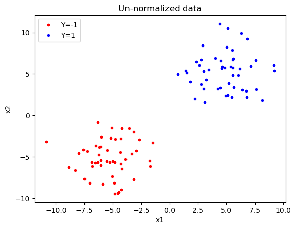

```python
import numpy as np
import matplotlib.pyplot as plt

#initialize an array of zeros to store the samples

#function to plot all of the scatter points
def plot_points(X,Y,show_plt = True,plt_title = "Un-normalized data"):
    plt.gca()
    plt.plot(X[0:50,0],X[0:50,1],'r.',label="Y=-1")
    plt.plot(X[50:,0],X[50:,1],'b.',label="Y=1")
    plt.xlabel("x1")
    plt.ylabel("x2")
    plt.title(plt_title)
    plt.legend()
    if show_plt:
        plt.show()

def generate_dataset(seed_val = 42):
    np.random.seed(seed=seed_val)
    X = np.zeros((100,2))
    Y = np.zeros((100,1),dtype= int)

    #configure the negative values
    Y[0:50] = -1
    mean = [-5,-5]
    cov = [[5,0],[0,5]]
    X[0:50] = np.random.multivariate_normal(mean,cov,50)

    #configure the positive values
    Y[50:] = 1
    mean = [5,5]
    cov = [[5,0],[0,5]]
    X[50:] = np.random.multivariate_normal(mean,cov,50)

    return X,Y

X,Y = generate_dataset()
plot_points(X,Y)
```

## Problem 4.2

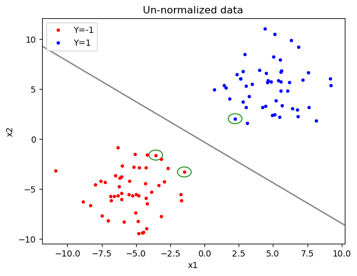

```python
from matplotlib.pyplot import plot
from sklearn import svm
from sklearn.inspection import DecisionBoundaryDisplay

def compute_SVM(X,Y,C_val,circle_svs = False,plt_margins = False):

    clf = svm.SVC(kernel="linear", C=C_val)
    clf.fit(X,Y.transpose()[0])
    support_vectors = clf.support_vectors_

    ax = plt.gca()
    #put a circle around the support vectors
    if circle_svs:
        for point in support_vectors:
            cir = plt.Circle(point,0.5,color='g',fill = False)
            ax.add_patch(cir)

    if plt_margins:
        desired_levels = [-1,0,1]
    else:
        desired_levels = [0]
    disp = DecisionBoundaryDisplay.from_estimator(
        clf,
        X,
        plot_method="contour",
        colors="k",
        levels=desired_levels,
        alpha=0.5,
        linestyles=["-"],
        ax=ax
    )

    return clf

X,Y = generate_dataset(seed_val=42)
plot_points(X,Y,False)
compute_SVM(X,Y,1.0,circle_svs=True,plt_margins=False)
plt.show()
```

# Problem 4.3

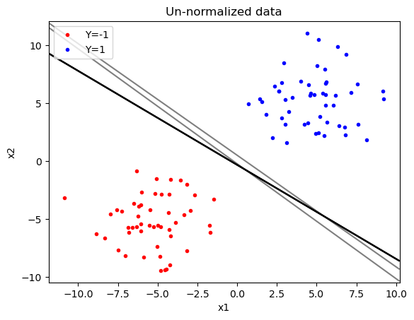

```python
#write a function to test multiple c values
def compute_multiple_SVMs(X,Y,C_vals_to_test):
    num_sv = np.zeros(C_vals_to_test.size)
    for i in range(0,len(C_vals_to_test)):
        clf = compute_SVM(X,Y,C_vals_to_test[i],circle_svs=False,plt_margins=False)
        num_sv[i] = clf.n_support_.sum()

    return num_sv

def plot_sv_vs_C_val(num_sv,C_vals_to_test):
    ax = plt.gca()
    plt.plot(np.log(C_vals_to_test),num_sv,'r-')
    plt.xlabel("log(c value)")
    plt.ylabel("num support vectors")
    plt.title("C vs Number of Support Vectors")
    plt.legend()

X,Y = generate_dataset(seed_val=42)
plot_points(X,Y,show_plt=False)

C_vals_to_test = np.array([1e-4,3e-2,5e-2,1e-1,1,3,7,20,1e8])

num_sv = compute_multiple_SVMs(X,Y,C_vals_to_test)
```

```
No artists with labels found to put in legend.  Note that artists whose label start with an underscore are ignored when legend() is called with no argument.
```

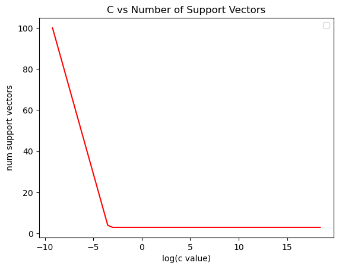

```python
plot_sv_vs_C_val(num_sv,C_vals_to_test)
```

As the value of C increases, the number of support vectors decreases. The reason for this larger values of C result in smaller margins which decreases the number of support vectors

## Problem 4.4

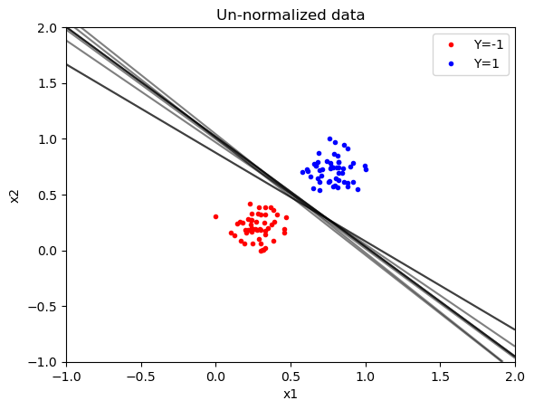

```python
def normalize_features(X):
    for i in range(0,X.shape[1]):
        #determine the max value
        max = np.amax(X[:,i])

        #determine the min value
        min = np.amin(X[:,i])

        #determine the range of values
        spread = max - min

        X[:,i] = np.subtract(X[:,i],min)
        X[:,i] = np.multiply(X[:,i],1/spread)

    return X

X,Y = generate_dataset(seed_val=42)
X_normalized = normalize_features(X)
plot_points(X_normalized,Y,show_plt=False)
num_sv = compute_multiple_SVMs(X_normalized,Y,C_vals_to_test)
```

```
No artists with labels found to put in legend.  Note that artists whose label start with an underscore are ignored when legend() is called with no argument.
```

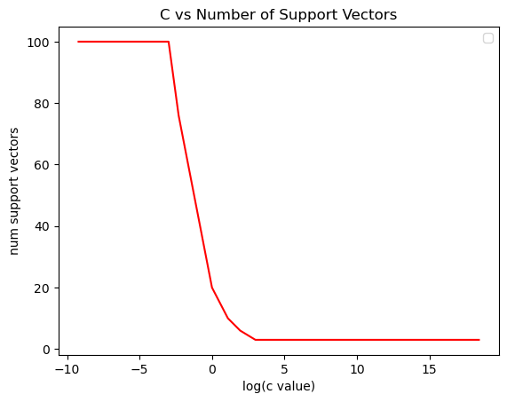

```python
plot_sv_vs_C_val(num_sv,C_vals_to_test)
```

The decision boundaries are different from the previous question over the same values of C. A) This implies that for normalized data, the geometric margin decreases. B) for each feature, when we normalize the data, each feature has the same relative effect on the predictions of the trained model. This is different for unnormalized data where it is possible that some features have a much large effect on the predictions of the trained model. With that said, for this data set, we didn't really observe this effect, but this is only a unique case and wouldn't necessarially be the case in practical applications

## Problem 4.5

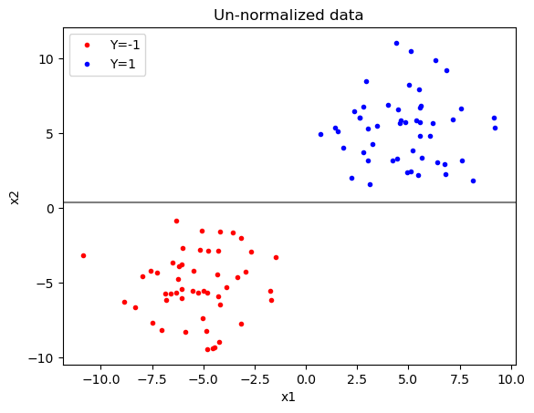

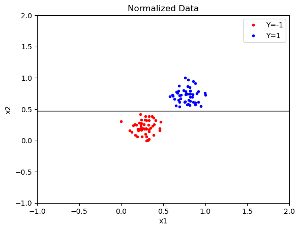

```python
from sklearn.ensemble import AdaBoostClassifier

def compute_BDT(X,Y):

    clf = AdaBoostClassifier()
    clf.fit(X,Y.transpose()[0])

    ax = plt.gca()
    #put a circle around the support vectors
    disp = DecisionBoundaryDisplay.from_estimator(
        clf,
        X,
        plot_method="contour",
        colors="k",
        levels=[0],
        alpha=0.5,
        linestyles=["-"],
        ax=ax
    )

    return clf

X,Y = generate_dataset(seed_val=42)
clf = compute_BDT(X,Y)
plot_points(X,Y,show_plt=True)

X_normalized = normalize_features(X)
clf = compute_BDT(X_normalized,Y)
plot_points(X,Y,show_plt=True,plt_title="Normalized Data")
```

The boosted decision tree classifier that I used was the adaboost boosted decision tree method. While the directions called for us to plot both decision boundaries, I found it was helpful to plot them separately so that I could visualize how the data affected the plot. Overall, the data makes sense to me, but I didn't really expect the thresholds to be a horizontal line. I had expected the plots to be more of a diagonal line which would indicate that the boosted decision tree classifier was equally weighting both features. However, based on these plots, it loos like it only focused on one of the features (which makes sense since either feature can be used to distinguish the data). With that said, the plots do differ from eachother as the threshold moves to the midpoint between the two data sets. For example, on the un-normalized dataset, the threshold is close to zero. While for the normalized data set, the threshold is closer to 0.5 which makes sense.

# Problem 5

## Problem 5.1

See Overleaf writeup

## Problem 5.2

```python
import csv
# define several support funcitons


def load_dict(file_name):
    """read the dictionary file and save it into a dictionary

    Args:
        file_name (string): the path to the dictionary file

    Returns:
        dict: the parsed dictionary
    """

    #open the file
    f = open(file_name,'r')

    #load dict file into a list using csvread
    file_data = csv.reader(f,delimiter=' ')

    #convert list into dictionary object
    data_dict = {}
    for row in file_data:
        data_dict[row[0]] = int(row[1])

    #return the dictionary and close the file
    f.close()
    return data_dict

def load_movie_reviews(file_name,word_dict):
    #open the movie reviews csv
    f = open(file_name,'r')

    #load the movie reviews into a list using csvread
    file_data = csv.reader(f,delimiter="\t")

    #initialize a list of reviews
    labels = []
    reviews = []

    #for each review, create a dictionary of all of words in the review\
    for review in file_data:

        #save the label
        labels.append(int(review[0]))

        #parse and save the review
        reviews.append(parse_review(review[1],word_dict))

        #save it in the list of reviews
    return labels,reviews

def parse_review(review,word_dict):
    #split the review into a list of words
    review_words = review.split()

    review_dict = {}
    #for each word
    for word in review_words:

        #if the word is in word_dict, add the word_dict key
        if word in word_dict:
            idx = word_dict[word]
            review_dict[idx] = 1

    #return the dictionary with the words
    return review_dict


word_dict = load_dict('dict.txt')
Y,X = load_movie_reviews('moviereview.tsv',word_dict)

print(X[1])
```

```
{417: 1, 307: 1, 45: 1, 418: 1, 32: 1, 419: 1, 420: 1, 421: 1, 2: 1, 422: 1, 423: 1, 58: 1, 424: 1, 92: 1, 39: 1, 83: 1, 70: 1, 425: 1, 51: 1, 426: 1, 396: 1, 427: 1, 222: 1, 22: 1, 101: 1, 428: 1, 429: 1, 430: 1, 431: 1, 432: 1, 433: 1, 434: 1, 435: 1, 436: 1, 437: 1, 438: 1, 439: 1, 440: 1, 441: 1…
```

## Problem 5.3

```python
from sklearn.model_selection import train_test_split
import math
#declare several support functions

#function to compute dot product efficiently
def compute_sparse_dot_product(theta,x_val):
    """Compute a sparse dot product

    Args:
        theta (array of flaots): the theta value
        x_val (array of dict): array of dicts for the x values

    Returns:
        _type_: _description_
    """
    sum = 0
    for idx in x_val:
        sum += theta[idx]

    #add the last index of theta to the sum as well
    sum += theta[-1]
    return sum

#function to increment the theta
def update_theta(theta,theta_new,eta):
    """Update the current theta with a newly computed theta

    Args:
        theta (array of floats): the previous theta
        theta_new (array of floats): the new theta
        eta (float): the learning rate

    Returns:
        array of floats: the new theta
    """
    for i in range(0,len(theta)):
        theta[i] -= eta * theta_new[i]

    return theta


#function to train the model
def train_logistic_regression(x_train,y_train,word_dict, eta=1e-4,num_epochs=30):
    """Train a logistic regression model

    Args:
        x_train (list of dictionaries): The training set
        y_train (list of ints): the training set of Y's
        word_dict (dict): a dictionary of all possible words
        eta (float, optional): the learning rate. Defaults to 1e-4.
        num_epochs (int, optional): number of training epochs. Defaults to 30.

    Returns:
        _type_: _description_
    """
    #initialize theta to all zeros
    theta = [0.0] *(len(word_dict) + 1)

    #while the number of epochs is less than num_epochs, update eta
    epoch = 0
    while epoch < num_epochs:
        #initialize a new theta
        theta_new = [0.0] * (len(word_dict) + 1)

        #for each data point
        for i in range(0,len(x_train)):
            x_i = x_train[i]
            y_i = y_train[i]
            #compute theta_xi
            theta_xi = compute_sparse_dot_product(theta,x_i)

            #for each feature in that data point
            for idx in x_i:
                if y_i == 1:
                    theta_new[idx] -= (1/(1 + math.exp(theta_xi)))

                elif y_i == 0:
                    theta_new[idx] += (1/(1 + math.exp(-1 * theta_xi)))

            #for the "last" feature in each data point (p+1 feature)
            if y_i == 1:
                theta_new[-1] -= (1/(1 + math.exp(theta_xi)))
            else:
                theta_new[-1] += (1/(1 + math.exp(-1 * theta_xi)))

        #update theta
        theta = update_theta(theta, theta_new,eta)
        epoch += 1
    return theta

def predict_values(x_values,word_dict,theta):
    """Predict the values of Y, for a given x and theta

    Args:
        x_values (array of dicts): an list of dictionary objects for each x value
        word_dict (dict): a dictionary of available words
        theta (list of floats): A trained value of thetas

    Returns:
        list of floats: the predicted value for each x
    """
    y_predicted = []

    for x in x_values:
        theta_x = compute_sparse_dot_product(theta,x)
        p_y_1 = (1/(1 + math.exp(-1 * theta_x)))

        if p_y_1 > 0.5:
            y_predicted.append(1)
        else:
            y_predicted.append(0)

    return y_predicted

#split the data into testing and training data
X_train, X_test, Y_train, Y_test = train_test_split(X, Y, test_size=0.2, random_state=42)

theta = train_logistic_regression(X_train,Y_train,word_dict,1e-4,100)
```

```python
#measure the training error and the testing error
import sklearn.metrics

#compute training error
y_predicted = predict_values(X_train,word_dict,theta)
training_accuracy = sklearn.metrics.accuracy_score(Y_train,y_predicted)

#compute testing error
y_predicted = predict_values(X_test,word_dict,theta)
testing_accuracy = sklearn.metrics.accuracy_score(Y_test,y_predicted)

out_string = "Training Accuracy {:0.3f}%\nTesting Accuracy: {:0.3f}%".format(training_accuracy,testing_accuracy)
print(out_string)
```

```
Training Accuracy 0.993%
Testing Accuracy: 0.875%
```

Note: While I had attempted to set my learning rate as a constant $\eta = 0.1$, I experienced the common "blow up" value error that was described on Ed. As such, I set a lower learning rate to avoid this issue. My algorithm remains the same, and I was still able to get very good testing and training accuracy for my model. Hopefully, this is still okay as its within the bounds of the problem

# Problem 6

## Problem 6.1

```python
import csv
import numpy as np
from sklearn.model_selection import train_test_split
# define support functions that will be used

# function to import the titanic data set
def import_data_set(file_name):
    """read and import the Titanic cs

    Args:
        file_name (string): the name of the file containing the data

    Returns:
        list: list of headers and data from the file
    """
    #open the file
    f = open(file_name,'r')

    #load dict file into a list using csvread
    file_data = csv.reader(f,delimiter=',')

    data_list = []
    #load the data into a list
    for sample in file_data:
        data_list.append(sample)

    #get the headers
    headers = data_list[0]
    data = data_list[1:]
    return headers,data

def determine_valid_columns(headers,data):
    """Determine the columns that don't have N/A in them

    Args:
        headers (list): the headers for the dataset
        data (list): the data from the dataset

    Returns:
        list: list of the valid headers and valid columns (1 for valid, 0 for invalid)
    """
    #parse through the data, and identify the columns that have N/A values
    valid_columns = [1] * len(headers)
    for i in range(0,len(data)):
        for j in range(0,len(headers)):
            if data[i][j] == '':
                valid_columns[j] = 0

    #create a list of indicies for the valid columns
    valid_column_indicies = []
    valid_headers = []
    for i in range(0,len(headers)):
        if valid_columns[i] == 1:
            valid_column_indicies.append(i)
            valid_headers.append(headers[i])

    return valid_column_indicies,valid_headers

def preprocess_data(headers,data):

    #determine the valid columns
    valid_col_indicies,valid_headers = determine_valid_columns(headers,data)

    #convert the gender columns to 0 and 1
    gender_col = headers.index("Sex")
    for i in range(0,len(data)):
        if data[i][gender_col] == 'male':
            data[i][gender_col] = 0
        else:
            data[i][gender_col] = 1

    #save the data into arrays that can be used to train the data
    X = np.empty((len(data),len(valid_col_indicies)-1))
    Y = np.empty(len(data),dtype=int)

    for i in range(0,len(data)):
        Y[i] = int(data[i][0])
        for j in range(1,len(valid_col_indicies)):
            X[i,j-1] = float(data[i][valid_col_indicies[j]])


    return X,Y

headers,data = import_data_set("Titanic.csv")
X,Y = preprocess_data(headers,data)

X_train, X_test, Y_train, Y_test = train_test_split(X, Y,test_size=0.2, shuffle=False)
#
```

## Problem 6.2

```python
from sklearn.ensemble import RandomForestClassifier
from sklearn.ensemble import AdaBoostClassifier
import time

#fit a boosted deision tree
start = time.time()
bt = AdaBoostClassifier()
bt.fit(X_train,Y_train)
end = time.time()

accuracy = bt.score(X_test,Y_test)

training_time = end-start
out_string = "Boosted decision tree: accuracy: {:.2}%, training time: {:.003}s".format(accuracy,training_time)
print(out_string)



#generate a random forest
start = time.time()
rf = RandomForestClassifier()
rf.fit(X_train,Y_train)
end = time.time()

accuracy = rf.score(X_test,Y_test)

training_time = end-start
out_string = "Random Forest: accuracy: {:.2f}%, training time: {:.003}s".format(accuracy,training_time)

print(out_string)
```

```
Boosted decision tree: accuracy: 0.79%, training time: 0.0493s
Random Forest: accuracy: 0.80%, training time: 0.0977s
```

The Random Forest implementation took twice as long to train compared to the boosted decision tree. This is likely the case because by default, the algorithm is training 100 trees with no maximum depth which likely significantly increases training time.

## Problem 6.3

```
Test Set Metrics

Boosted decision tree: accuracy: 0.79
Random Forest: accuracy: 0.8
```

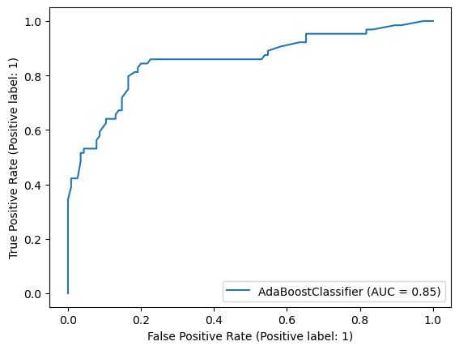

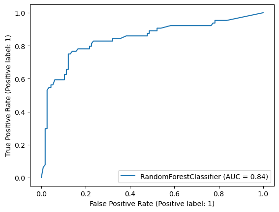

```
Training Set Metrics
Boosted decision tree: accuracy: 0.82
Random Forest: accuracy: 0.93
```

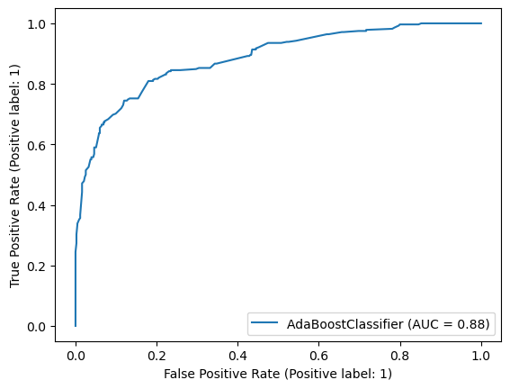

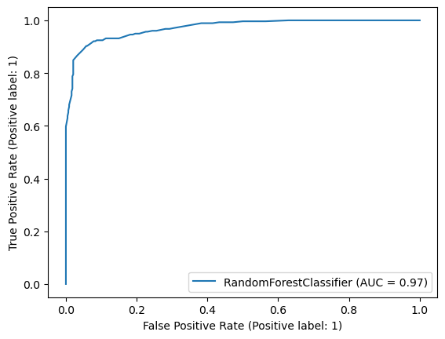

```python
from sklearn.model_selection import GridSearchCV
from sklearn.model_selection import GroupKFold
from sklearn.model_selection import cross_val_score
from sklearn import metrics
import matplotlib.pyplot as plt

#use grid search to train a boosted decision tree
bt = AdaBoostClassifier()
parameters = {'n_estimators':(10,100,200)}
clf = GridSearchCV(bt,parameters,cv=5)
clf.fit(X_train,Y_train)
bt_best = clf.best_estimator_

#use grid search to train a random forest
rf = RandomForestClassifier()
parameters = {'n_estimators':(10,100,200)}
clf = GridSearchCV(rf,parameters,cv=5)
clf.fit(X_train,Y_train)
rf_best = clf.best_estimator_

print("Test Set Metrics\n")
#determine the accuracy
accuracy = bt_best.score(X_test,Y_test)
out_string = "Boosted decision tree: accuracy: {:.2}".format(accuracy)
print(out_string)
accuracy = rf_best.score(X_test,Y_test)
out_string = "Random Forest: accuracy: {:.2}".format(accuracy)
print(out_string)
metrics.RocCurveDisplay.from_estimator(bt_best,X_test,Y_test)
metrics.RocCurveDisplay.from_estimator(rf_best,X_test,Y_test)
plt.show()

print("Training Set Metrics")
#determine the accuracy
accuracy = bt_best.score(X_train,Y_train)
out_string = "Boosted decision tree: accuracy: {:.2}".format(accuracy)
print(out_string)
accuracy = rf_best.score(X_train,Y_train)
out_string = "Random Forest: accuracy: {:.2}".format(accuracy)
print(out_string)
metrics.RocCurveDisplay.from_estimator(bt_best,X_train,Y_train)
metrics.RocCurveDisplay.from_estimator(rf_best,X_train,Y_train)
plt.show()
```

Adaboost and Random Forest classifiers are similar in some ways and different in a few. To start, Adaboost and the random forest are both comprised of a collection of simplier classifiers. For the random forest implementation, this is a set of decision trees. Depending on the boosting implementation, this can also be a set of decision trees or a set of decision stumps. What is different is in how the algorithms combine those outputs. For a random forest, the algorithm simply takes the majority vote from all of the decision trees in the forest. However, for boosting, the algorithm in essence weights the samples that are the the most difficult to classify and also searches for the optimal classifier for each iteration. Thus, the final output of boosting is a weighted sum of a set of simple classifiers. As such, adaboost is a bit different than random forest.

As far as the results for my particular trials, based on the ROC plots that I generated, it appears that the Random Forest overfit the training set a bit more than the boosted decision tree method. When looking at the ROC curves and the accuracy values, the random forest implementation achieved significantly higher accuracy on the training set than it did on the test set. This is compared to the boosted decision tree classifier which had similar results on both the training and test sets.

# Problem 7

```
Training Accuracy: 0.996
Testing Accuracy: 0.942
```

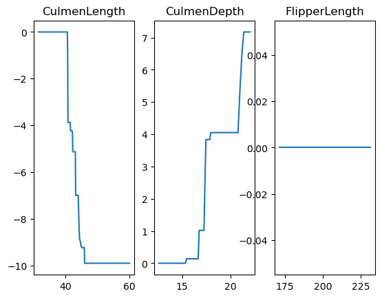

```python
import numpy as np
import pandas as pd
import matplotlib.pyplot as plt
from sklearn.linear_model import LogisticRegression
from sklearn.model_selection import train_test_split


#function to compute all of the different thresholds for the data
def compute_feature_thresholds(data):
    data_sorted = np.sort(data)
    thresholds = []

    #add the first point
    thresholds.append(data_sorted[0]-0.5)
    for i in range(1,len(data_sorted)):
        if data_sorted[i] != data_sorted[i-1]:
            mid_point = float((data_sorted[i] + data_sorted[i-1]))/2.0
            thresholds.append(mid_point)

    thresholds.append(data_sorted[-1] + 0.5)
    return thresholds

def binarize_feature(data,thresholds):
    binarized_array = np.zeros((data.shape[0],len(thresholds)))

    for i in range(0,data.shape[0]):
        for j in range(0,len(thresholds)):
            if data[i] <= thresholds[j]:
                binarized_array[i,j] = 1

    return binarized_array

def compute_thresholds(X):
    num_features = X.shape[1]
    thresholds = []
    num_binarized_features = 0
    feature_indicies = []
    for i in range(0,num_features):
        thresholds.append(compute_feature_thresholds(X[:,i].transpose()))
        feature_indicies.append((num_binarized_features,num_binarized_features + len(thresholds[i])))
        num_binarized_features += len(thresholds[i])

    return thresholds,num_binarized_features,feature_indicies

def binarize_dataset(X,thresholds,num_binarized_features,feature_indicies):
    #initialize an array to binarize the features
    num_features = X.shape[1]
    binarized_data = np.zeros((X.shape[0],num_binarized_features))
    for i in range(0,num_features):
        start = feature_indicies[i][0]
        end = feature_indicies[i][1]
        binarized_data[:,start:end] = binarize_feature(X[:,i],thresholds[i])

    return binarized_data

#function to get the Y values for the shape functions
def get_dependency_vals(coefficients,feature_indicies):
    dependency_vals = []
    for i in range(0,len(feature_indicies)):
        start = feature_indicies[i][0]
        end = feature_indicies[i][1]
        feature_dependency_vals = np.zeros(len(coefficients[start:end]))
        feature_dependency_vals[0] = coefficients[start]
        for j in range(1,len(feature_dependency_vals)):
            feature_dependency_vals[j] = feature_dependency_vals[j-1] + coefficients[start + j]
        dependency_vals.append(feature_dependency_vals)

    return dependency_vals

def plot_shape_fns(thresholds,dependency_vals,train_cols):
    plt.figure()
    fig, axs = plt.subplots(1,len(thresholds))

    for i, ax in enumerate(axs):
        ax.plot(thresholds[i], dependency_vals[i])
        #if i == 0:
        #   ax.set_ylim(-30,30)
        ax.set_title(train_cols[i])

df = pd.read_csv('penguins_trunc.csv')

train_cols = df.columns[0:-1]
label = df.columns[-1]
X = df[train_cols].to_numpy(dtype=float)
Y = df[label].to_numpy()



#split into  test and train data sets
thresholds,num_binarized_features,feature_indicies = compute_thresholds(X)
X_bin = binarize_dataset(X,thresholds,num_binarized_features,feature_indicies)

X_train, X_test, Y_train, Y_test = train_test_split(X_bin, Y, test_size=0.2, random_state=42)

clf = LogisticRegression(penalty="l1",solver="liblinear")
clf.fit(X_train,Y_train)
#training accuracy
accuracy = clf.score(X_train,Y_train)
out_string = "Training Accuracy: {:.3f}".format(accuracy)
print(out_string)
#testing accuracy
accuracy = clf.score(X_test,Y_test)
out_string = "Testing Accuracy: {:.3f}".format(accuracy)
print(out_string)

#get the coefficients
coeffs = clf.coef_

#get the dependency values
dependency_vals = get_dependency_vals(coeffs.transpose(),feature_indicies)

## plotting
plot_shape_fns(thresholds,dependency_vals,train_cols)
```